# Part I - (Ford GoBike System Data)

## Introduction

> This data set includes information about individual rides made in a bike-sharing system covering the greater San Francisco Bay area.

## Preliminary Wrangling

```python
# import all packages and set plots to be embedded inline
import numpy as np
import pandas as pd
import matplotlib.pyplot as plt
import seaborn as sb
import math

%matplotlib inline
```

> Load in your dataset and describe its properties through the questions below. Try and motivate your exploration goals through this section.

```python
df = pd.read_csv('201902-fordgobike-tripdata.csv')
```

first. lets look at the structure of our dataset

```python
df.shape
```

```
(183412, 16)
```

so our dataset contains 183412 rows and 16 columns

now let's look at our columns one by one. and identify the meaning of each column to select all interesting columns that will be included in our exploratory data visualization

```python
df.head(10)
```

|  | duration_sec | start_time | end_time | start_station_id | start_station_name | start_station_latitude | start_station_longitude | end_station_id | end_station_name | end_station_latitude | end_station_longitude | bike_id | user_type | member_birth_year | member_gender | bike_share_for_all_trip |
| --- | --- | --- | --- | --- | --- | --- | --- | --- | --- | --- | --- | --- | --- | --- | --- | --- |
| 0 | 52185 | 2019-02-28 17:32:10.1450 | 2019-03-01 08:01:55.9750 | 21.0 | Montgomery St BART Station (Market St at 2nd St) | 37.789625 | -122.400811 | 13.0 | Commercial St at Montgomery St | 37.794231 | -122.402923 | 4902 | Customer | 1984.0 | Male | No |
| 1 | 42521 | 2019-02-28 18:53:21.7890 | 2019-03-01 06:42:03.0560 | 23.0 | The Embarcadero at Steuart St | 37.791464 | -122.391034 | 81.0 | Berry St at 4th St | 37.775880 | -122.393170 | 2535 | Customer | NaN | NaN | No |
| 2 | 61854 | 2019-02-28 12:13:13.2180 | 2019-03-01 05:24:08.1460 | 86.0 | Market St at Dolores St | 37.769305 | -122.426826 | 3.0 | Powell St BART Station (Market St at 4th St) | 37.786375 | -122.404904 | 5905 | Customer | 1972.0 | Male | No |
| 3 | 36490 | 2019-02-28 17:54:26.0100 | 2019-03-01 04:02:36.8420 | 375.0 | Grove St at Masonic Ave | 37.774836 | -122.446546 | 70.0 | Central Ave at Fell St | 37.773311 | -122.444293 | 6638 | Subscriber | 1989.0 | Other | No |
| 4 | 1585 | 2019-02-28 23:54:18.5490 | 2019-03-01 00:20:44.0740 | 7.0 | Frank H Ogawa Plaza | 37.804562 | -122.271738 | 222.0 | 10th Ave at E 15th St | 37.792714 | -122.248780 | 4898 | Subscriber | 1974.0 | Male | Yes |
| 5 | 1793 | 2019-02-28 23:49:58.6320 | 2019-03-01 00:19:51.7600 | 93.0 | 4th St at Mission Bay Blvd S | 37.770407 | -122.391198 | 323.0 | Broadway at Kearny | 37.798014 | -122.405950 | 5200 | Subscriber | 1959.0 | Male | No |
| 6 | 1147 | 2019-02-28 23:55:35.1040 | 2019-03-01 00:14:42.5880 | 300.0 | Palm St at Willow St | 37.317298 | -121.884995 | 312.0 | San Jose Diridon Station | 37.329732 | -121.901782 | 3803 | Subscriber | 1983.0 | Female | No |
| 7 | 1615 | 2019-02-28 23:41:06.7660 | 2019-03-01 00:08:02.7560 | 10.0 | Washington St at Kearny St | 37.795393 | -122.404770 | 127.0 | Valencia St at 21st St | 37.756708 | -122.421025 | 6329 | Subscriber | 1989.0 | Male | No |
| 8 | 1570 | 2019-02-28 23:41:48.7900 | 2019-03-01 00:07:59.7150 | 10.0 | Washington St at Kearny St | 37.795393 | -122.404770 | 127.0 | Valencia St at 21st St | 37.756708 | -122.421025 | 6548 | Subscriber | 1988.0 | Other | No |
| 9 | 1049 | 2019-02-28 23:49:47.6990 | 2019-03-01 00:07:17.0250 | 19.0 | Post St at Kearny St | 37.788975 | -122.403452 | 121.0 | Mission Playground | 37.759210 | -122.421339 | 6488 | Subscriber | 1992.0 | Male | No |

### What is the structure of your dataset?

our dataset contains 183412 individual rides and 16 columns.

#### the columns :

-duration_sec:  
-start_time:  
-end_time  
-start_station_id  
-start_station_name  
-start_station_latitude  
-start_station_longitude  
-end_station_id  
-end_station_name  
-end_station_latitude  
-end_station_longitude  
-bike_id  
-user_type  
-member_birth_year  
-member_gender  
-bike_share_for_all_trip

no need to describe each column since they are very clear and describe them self.

### What is/are the main feature(s) of interest in your dataset?

> -duration_sec:  
> -start_station_name  
> -end_station_name  
> -user_type  
> -member_birth_year  
> -member_gender  
> -bike_share_for_all_trip  
> .

all theses features(columns) will be in using in the Exploration and i am very interested to figuring out the what factor that make the rider spend more time and what feature that make people rent a bike(what factor will increase the number of individual rides) ?

### What features in the dataset do you think will help support your investigation into your feature(s) of interest?

> -start_time:  
> -end_time  
> -start_station_id  
> -start_station_latitude  
> -start_station_longitude  
> -end_station_id  
> -end_station_latitude  
> -end_station_longitude  
> -bike_id

all these features(columns) will not be in using in the Exploration . because they seem thay do not relevant in our goal

## data Wrangling

before we go to the Exploration. let do some data Wrangling to make our analysis possible

let first drop all unnecessary columns that are mentioned above.

```python
df.drop(['start_time','end_time','start_station_id','start_station_latitude','start_station_longitude','end_station_id','end_station_latitude','end_station_longitude','bike_id'],inplace=True,axis=1)
```

let chack if there are any missing values.

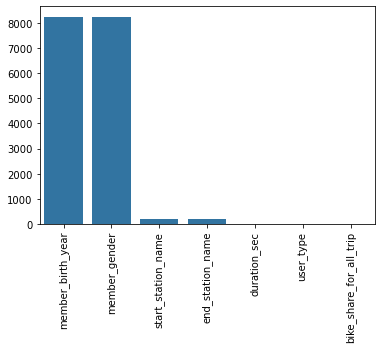

```python
# get all columns with their number of missing values
missing_values = df.isna().sum().sort_values(ascending=False)
base_color = sb.color_palette()[0]
sb.barplot(missing_values.index.values, missing_values,color=base_color);

# rotate the x-axis titles to prevent the overlapping
plt.xticks(rotation=90) ;
```

there are a huge number of missing values in member_birth_year and member_gender columns since they are very important columns that will be used leter. lets drop all missing value rows

```python
df.dropna(inplace=True)
#reset the index
df.index=range(df.shape[0])
```

the duration in a seconds absolutely is not a good idea. It is difficult for a person to comprehend the time in a second unit. so lets change it to minutes

```python
df['duration_sec'] = df['duration_sec']/60
df['duration_sec'] = df['duration_sec'].round(decimals =0)
df['duration_sec']= df['duration_sec'].astype("int32")

df.rename(columns={"duration_sec":"duration_min"},inplace=True)
```

finally , member_birth_year column must be integer rather than float. let's change the data type to integer.

```python
df["member_birth_year"] = df["member_birth_year"].astype("int64")
```

## Univariate Exploration

> In this section, investigate distributions of individual variables. If you see unusual points or outliers, take a deeper look to clean things up and prepare yourself to look at relationships between variables.

the bar and pie charts will be used frequently in this section. so let's define a function for each one.

```python
def barchart(serias,df,size,rotation):
    base_color = sb.color_palette()[0]

    # gets each type with its count
    na_counts = df[serias].value_counts()

    #set appropriate figure size
    plt.subplots(figsize=size)


    sb.countplot( data=df , x=serias, color=base_color , order = na_counts.index);




    # printing the count on the top of each bar
    for i in range (na_counts.shape[0]):
        count = na_counts[i]


        plt.text(i, count+10, count, ha = 'center')

        plt.xticks(rotation=rotation) ;
```

```python
def piechart(serias):
    sorted_counts = df[serias].value_counts()

    plt.subplots(figsize=(7,7))
    plt.pie(sorted_counts, labels = sorted_counts.index, startangle = 90, counterclock = False,autopct='%1.1f%%', shadow=True);
```

## question 1 : What is more between genders riding a bike ?

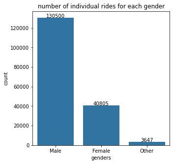

```python
barchart('member_gender',df,(5,5),0);
plt.title("number of individual rides for each gender");
plt.xlabel("genders");
```

Observations: Males are the most bike-riding person by a very large margin !!. Then comes the females .This big difference may explain to us that the gender is one of the factors affecting the number of bike rides. now let's see the percentage of each gender.

## question 2 :what is the percentage of each gender in individual rides ?

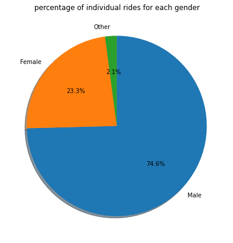

```python
piechart('member_gender')
plt.title("percentage of individual rides for each gender");
```

Observations: The result reinforces the observation in the previous question. male percentage is 74.6% !!. also, This is a great indication of the importance of the gender factor in the number of individual rides

## question 3 : which station that the people prefer to start with? is actually the place is important factor ?

since there are large number of stations, we will take the top 15 only.

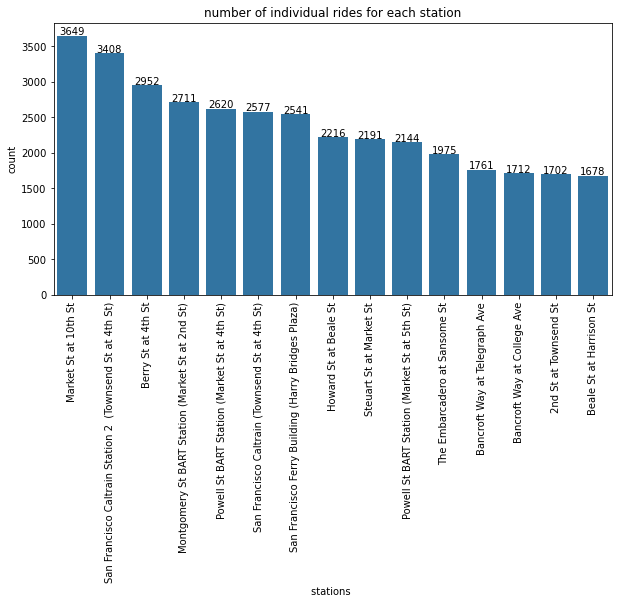

```python
# gets top 15 stations in terms of count
station = df["start_station_name"].value_counts()[:15].index

# changing the array to a tuple to be injected in the query
station = tuple(station)

# getting the top 20 stations in terms of count
new_df= df.query("start_station_name in {}".format(station))

barchart("start_station_name",new_df,(10,5),90)

plt.xlabel("stations ");
plt.title("number of individual rides for each station");
```

Observations: It is very clear that some stations are more popular than others. And that there are stations that are preferred over others. Therefore, it may be that some stations actually attract more customers to them. Based on this, it can be said that the place can be a factor affecting the number of bike rides.

## question 4 : what is the most common user type(subscriber or customer ) ?. does the user type is important factor ?

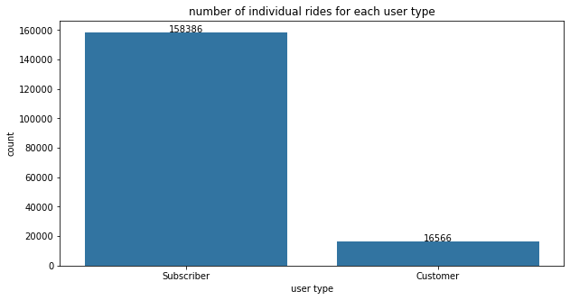

```python
barchart("user_type",df,(10,5),0)
plt.title("number of individual rides for each user type");
plt.xlabel("user type");
```

Observations: subscribers are the most bike-riding person by a very large margin !!.This big difference may explain to us that the user type is one of the factors affecting the number of bike rides.

## question 5 : what is the percentage of each user type(subscriber or customer) in individual rides ?

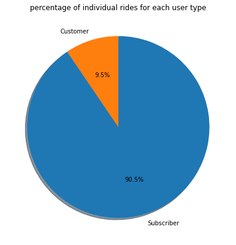

```python
piechart("user_type");
plt.title("percentage of individual rides for each user type");
```

Observations: The result reinforces the observation in the previous question. subscribers percentage is 90.5% !!. also, This is a great indication of the importance of the user type factor in the number of individual rides

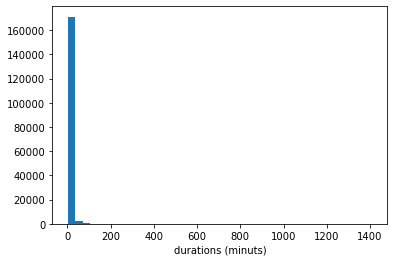

```python
#find the minimum value
minimum = df["duration_min"].min()

#find the maximum value
maximum = df["duration_min"].max()

# calculate the step value to make 40 bins
step = (maximum-minimum)/40

bins =np.arange(minimum , maximum + step, step);

plt.hist(data=df,x="duration_min",bins=bins);

plt.xlabel('durations (minuts)');
```

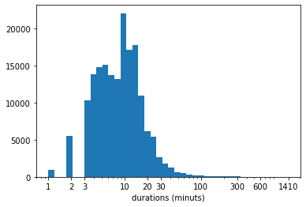

```python
minimum = math.log10(minimum)

maximum = math.log10(maximum)

step = (maximum-minimum)/40

bins = 10 ** np.arange(minimum, maximum+step, step)

ticks = [ 1,2, 3,10,20, 30, 100, 300, 600,1410]

labels = ['{}'.format(val) for val in ticks]

plt.hist(data = df, x = 'duration_min', bins = bins);

plt.xscale('log');

plt.xticks(ticks, labels);

plt.xlabel('durations (minuts)');
```

Observations: the data looked right-skewed a little pit with one peak between 3 and 25 minutes. duration is approximately bounded between 3 to 300 minutes .

## question 6 :what is the distribution of member birth years for all individual rides ?

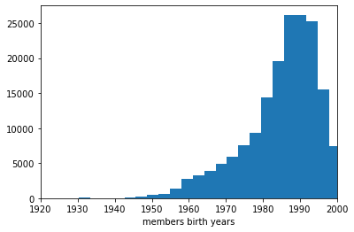

```python
#find the minimum value
minimum = df["member_birth_year"].min()

#find the maximum value
maximum = df["member_birth_year"].max()

# calculate the step value to make 40 bins
step = (maximum-minimum)/40

bins =np.arange(minimum , maximum + step, step);

plt.hist(data=df,x="member_birth_year",bins=bins);

plt.xlabel('members birth years')

plt.xlim((1920,2000));
```

Observations: the data looked left-skewed. And that's what we all expect, because cycling is a sport. Young people are the majority of sports practitioners.

### Discuss the distribution(s) of your variable(s) of interest. Were there any unusual points? Did you need to perform any transformations?

> in duration distribution. the distribution appears as a single vertical line on the left. the reason is there are outliers thats make our distribution unreadable. After that, I had to perform a log transformations. after that the distribution became more clear and readable. . Under the transformation, the data looked right-skewed a little pit.

> in member birth years distribution , there are a small number of outliers but they do not make observable effect. so i did not perform any transformations. the data looked left-skewed. And that's what we all expect, because cycling is a sport. Young people are the majority of sports practitioners.

### Of the features you investigated, were there any unusual distributions? Did you perform any operations on the data to tidy, adjust, or change the form of the data? If so, why did you do this?

> in duration distribution. are some gaps in the distribution. like 1m to 2m , 2m to 3m. i think it,s a problem with the data itself, i dont think that this preblem can be solved,

before me move to the next. lets remove all outliers

```python
df = df[df["duration_min"].between(df["duration_min"].quantile(.25), df["duration_min"].quantile(.75))]

#reset the index
df.index=range(df.shape[0])
```

## Bivariate Exploration

> In this section, investigate relationships between pairs of variables in your data. Make sure the variables that you cover here have been introduced in some fashion in the previous section (univariate exploration).

the "Adapted Bar Chart" and the "box plot" will be used frequently in this section. so let's define a function for each one.

```python
def Adapted_Bar_Chart(x,y,xlabel,ylabel,title):


    base_color = sb.color_palette()[0]

    sb.barplot(data=df, x=x, y=y, color=base_color)

    plt.ylabel(ylabel);
    plt.xlabel(xlabel);
    plt.title(title);
```

```python
def boxplot (x,y,xlabel,ylabel):
    sb.boxplot(data=df, y=y, x=x, color=base_color);
    plt.ylabel(ylabel);
    plt.xlabel(xlabel);
```

## question 7 :is the birth_year(age) will effect to the duration. do old people often take a short duration ?

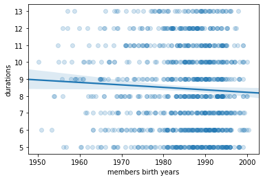

```python
np.random.seed(2018)
# take a 1000 random data points
sample = np.random.choice(df.shape[0], 1000, replace = False)
dfsubset = df.loc[sample]


g= sb.regplot(data = dfsubset, x = 'member_birth_year', y = 'duration_min', truncate=False, x_jitter=0.3, scatter_kws={'alpha':1/5});


plt.xlabel('members birth years')
plt.ylabel('durations');
```

the data points are very random and it is hard to find a specific pattern. it seems that the age has no effect to the duration. let's try to plot the same data in a heat map.

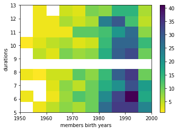

```python
plt.hist2d(data = dfsubset, x = 'member_birth_year', y = 'duration_min', cmin=0.5, cmap='viridis_r')
plt.colorbar()
plt.xlabel('members birth years')
plt.ylabel('durations');

#set the x and y limits to avoid the outliers
```

Also, no petterns can be found.

Observations: the data points are very random and it is hard to find a specific pattern. it seems that the age has no effect to the duration.

## question 8 : which user type(subscriber or customer ) tend to take more duration?

we will use Adaptation of Univariate Plots(Adapted Bar Chart) to solve this question

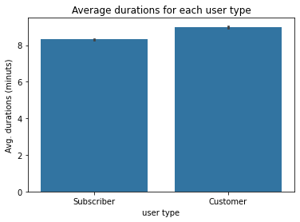

```python
Adapted_Bar_Chart('user_type','duration_min','user type','Avg. durations (minuts)',"Average durations for each user type")
```

Observations: , you may say that customers often prefer to take more duration.

## question 9 : Does gender affect duration?

we will use two visualization techniques to solve this question . Adaptation of Univariate Plots(Adapted Bar Charts) and the box plot

let's start with Adaptation of Univariate Plots(Adapted Bar Charts) .

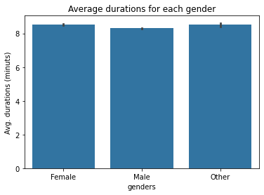

```python
Adapted_Bar_Chart('member_gender','duration_min','genders','Avg. durations (minuts)',"Average durations for each gender")
```

now let's move to the box plot .

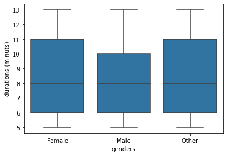

```python
boxplot('member_gender',"duration_min",'genders','durations (minuts)')

# limiting the y axis to prevent the outliers and focus on the box
```

Observations: based on the results from these visualization techniques. on average,females and "other" spand more duration than males

## question 10 : Is there a relationship between gender and year of birth (age)?

same as the previous question, we will use two visualization techniques to solve this question . Adaptation of Univariate Plots(Adapted Bar Charts) and the box plot.but additionally, we will try to see the members birthday years distribution on each gender(Faceting)

let's start with Adaptation of Univariate Plots(Adapted Bar Chart)

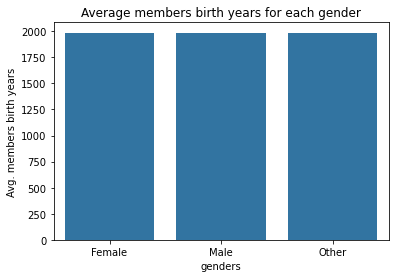

```python
Adapted_Bar_Chart('member_gender','member_birth_year','genders','Avg. members birth years',"Average members birth years for each gender")
```

approximately they have the same members birth years average

now let's move to the box plot .

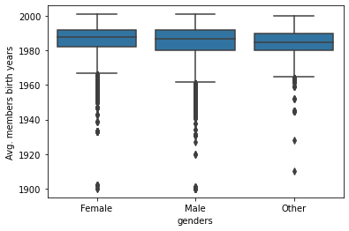

```python
boxplot('member_gender',"member_birth_year",'genders','Avg. members birth years')
```

there are a lot of outlines . which that may distort our conclusion. but all the boxes located on the same y axis

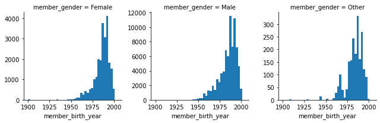

```python
minimum = df["member_birth_year"].min()

#find the maximum value
maximum = df["member_birth_year"].max()

# calculate the step value to make 40 bins
step = (maximum-minimum)/40

bins =np.arange(minimum , maximum + step, step);

g = sb.FacetGrid(data = df, col = 'member_gender',sharey=False)
g.map(plt.hist, "member_birth_year",bins = bins)
```

all gender have the same distribution approximately. the distribution is left skewed.

Observations: based on the results from these visualization techniques. there is no relationship between gender and year of birth , since all birth years for all genders are very similer to each other and no diffrence in avarage(age) and thay have the same distrubtion shape

### Talk about some of the relationships you observed in this part of the investigation. How did the feature(s) of interest vary with other features in the dataset?

> i interested to figuring out the what factor that make the rider spend more time. so i found two relationships with the duration. since our variables are numerical and categorical, identifying the relationship will not be accurate like when you have two numerical variables. :  
> 1-**duration and gender**: there are an observable difference on average duration time between genders. on average,females and "other" spand more duration than males.  
> 2-**duration and user type(subscriber or customer)**: there are a difference on average duration time between user types. the type "customer" is the one the highest average duration, then the subscriber. it seems that customers often prefer to take more duration

### Did you observe any interesting relationships between the other features (not the main feature(s) of interest)?

> i tried to find if there is a relationship between the member birth year(ages) and the member gender. but it seems there is no relationship

## Multivariate Exploration

> Create plots of three or more variables to investigate your data even further. Make sure that your investigations are justified, and follow from your work in the previous sections.

## question 11 : for each gender, what user type (subscriber or customer) takes more duration?

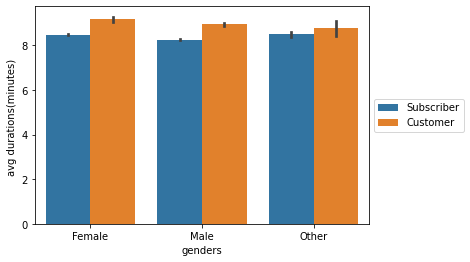

```python
ax = sb.barplot(data = df, x = 'member_gender', y = 'duration_min', hue = 'user_type')
ax.legend(loc = 8, ncol = 3, framealpha = 1, title = 'user type')
plt.legend(loc = 6, bbox_to_anchor = (1.0, 0.5))
plt.xlabel('genders')
plt.ylabel('avg durations(minutes) ');
```

## Conclusions

> I am very interested to figuring out the what factor that make the rider spend more time and what feature that make people rent a bike(what factor will increase the number of individual rides) .so I iasked 11 questions in order to find all factors or relationships thats make the indavuals spend more time or increase the number of individual rides.  
> here some factors and relationships I found:
> - genders can be a factor that increase the number of individual rides since 74.6% of the individual rides are males.
> - the user type is important factor that increase the number of individual rides since 90.5% of the individual rides are subscribers.
- the station can could be a factor that increase the number of individual rides since that some stations are more popular than others. And that there are stations that are preferred over others.
- most of the individual rides are young people.
- user type(subscriber or customer ) plays a role of individual ride duration. since on avarege, customers spend more time than subscriber.
- the gender can effect in individual ride duration.